# Data Project Proposal

Jason Bryer

### Data Preparation

```r
# load data
library(fivethirtyeight)
data(avengers)
```

### Research question

**You should phrase your research question in a way that matches up with the scope of inference your dataset allows for.**

Is there a relationship between the number of apperances, years since joining the Avengers, and the Avegenders honary status?

### Cases

**What are the cases, and how many are there?**

Each case represents an Avenger.

```r
nrow(avengers)
```

```
## [1] 173
```

### Data collection

**Describe the method of data collection.**

### Type of study

**What type of study is this (observational/experiment)?**

Observational

### Data Source

**If you collected the data, state self-collected. If not, provide a citation/link.**

Five Thirty Eight

https://fivethirtyeight.com/features/captain-america-civil-war-who-would-win/

### Dependent Variable

**What is the response variable? Is it quantitative or qualitative?**

The number of appearances of the Avenger (quantitative)

### Independent Variable

**You should have two independent variables, one quantitative and one qualitative.**

- Years since joining the Avengers (quantitative)
- The Avenger’s honary status (qualitative)

### Relevant summary statistics

**Provide summary statistics for each the variables. Also include appropriate visualizations related to your research question (e.g. scatter plot, boxplots, etc). This step requires the use of R, hence a code chunk is provided below. Insert more code chunks as needed.**

```r
summary(avengers$appearances)
```

```
##    Min. 1st Qu.  Median    Mean 3rd Qu.    Max.
##     2.0    58.0   132.0   414.1   491.0  4333.0
```

```r
sd(avengers$appearances)
```

```
## [1] 677.992
```

```r
psych::describe(avengers$appearances)
```

```
##    vars   n   mean     sd median trimmed    mad min  max range skew
## X1    1 173 414.05 677.99    132  252.15 154.19   2 4333  4331    3
##    kurtosis    se
## X1    10.36 51.55
```

```r
psych::describe(avengers$years_since_joining)
```

```
##    vars   n  mean    sd median trimmed   mad min max range skew kurtosis
## X1    1 173 26.55 30.37     19   20.15 20.76   0 115   115 1.87     2.98
##      se
## X1 2.31
```

```r
table(avengers$honorary)
```

```
##
##      Academy         Full     Honorary Probationary
##           17          138           16            2
```

```r
prop.table(table(avengers$honorary)) * 100
```

```
##
##      Academy         Full     Honorary Probationary
##     9.826590    79.768786     9.248555     1.156069
```

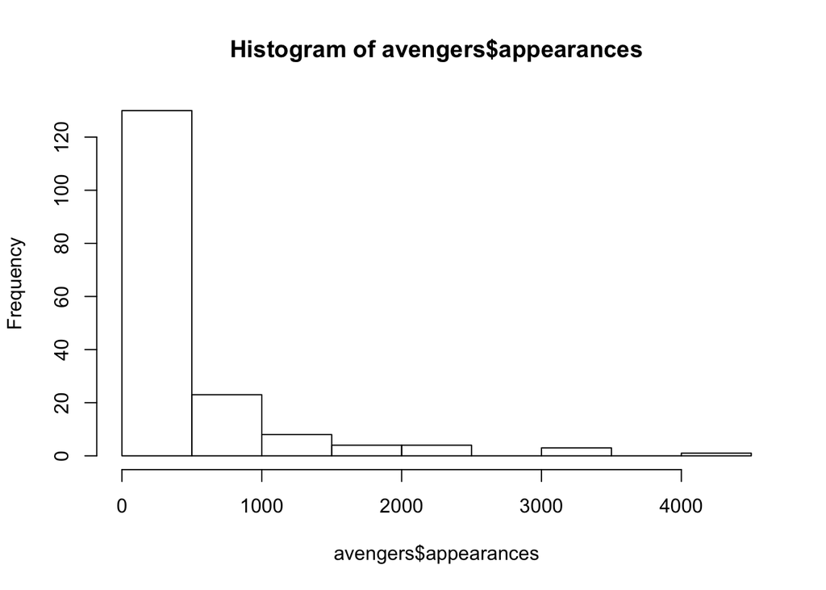

```r
hist(avengers$appearances)
```